# CS109B Lab 4: Support Vector Machines

# Support Vector Machines in R

There are two main implementations: `e1071::svm` provides an R interface to `libsvm`, and `kernlab::ksvm` provides a flexible implementation that can be extended at the R level. For the homework we recommend using the `e1071` implementation. In real life you should experiment and choose the approach you are most comfortable with.

# A simple first example

The `iris` data is often used for classification examples, and is a good place to start given it’s relative simplicity.

Let’s begin by classifying observations as `setosa` vs `other`.

```r
iris2 <- transform(iris, Species = factor(Species == "setosa",
                                          labels = c("other", "setosa")))
```

As usual, it’s a good idea to start by plotting the data.

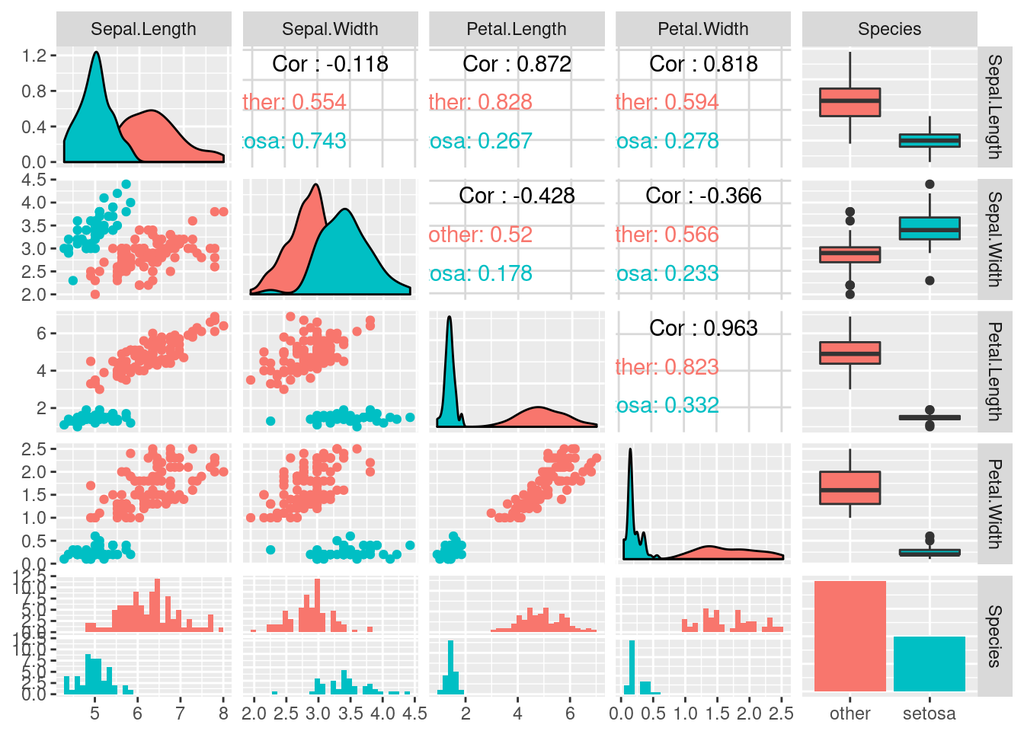

```r
library(ggplot2)
library(GGally)

ggpairs(iris2, mapping = aes(color = Species))
```

We can see that `Species` separates pretty cleanly along different pairs of attributes. Let’s start by considering just `Sepal.Width` and `Sepal.Length`.

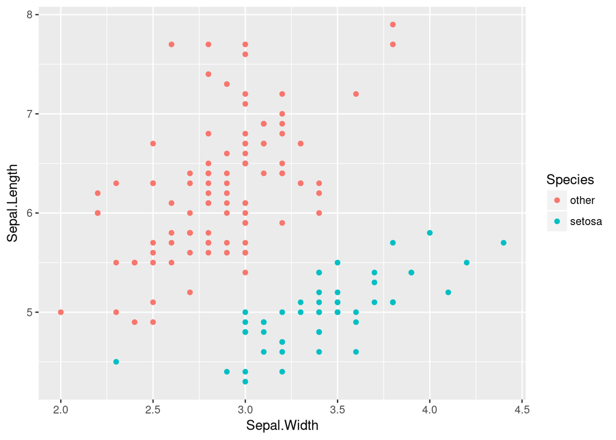

```r
ggplot(iris2,
       mapping = aes(x = Sepal.Width, y = Sepal.Length)) +
    geom_point(mapping = aes(color = Species))
```

We’ll start with a simple linear kernel to help us build up an intuition for how SVM works.

```r
library(e1071)

m <- svm(Species ~ Sepal.Width + Sepal.Length,
         data = iris2,
         kernel = "linear")

m
```

```
##
## Call:
## svm(formula = Species ~ Sepal.Width + Sepal.Length, data = iris2,
##     kernel = "linear")
##
##
## Parameters:
##    SVM-Type:  C-classification
##  SVM-Kernel:  linear
##        cost:  1
##       gamma:  0.5
##
## Number of Support Vectors:  12
```

The `svm` function returns a list of model statistics of class `svm`. There are a few methods available, including `plot` and `predict`:

```r
sapply(class(m), function(x) methods(class =x))
```

```
## $svm.formula
## no methods found
##
## $svm
## [1] plot    predict print   summary
## see '?methods' for accessing help and source code
```

The `plot` methods gives us a visualization of the observed and predicted class.

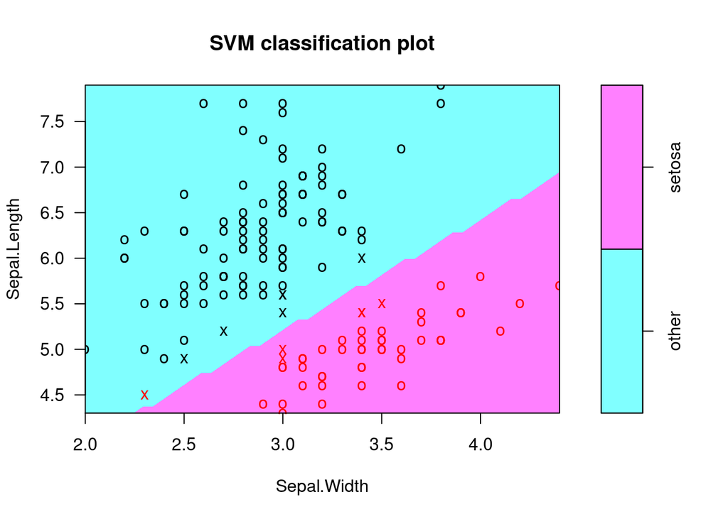

```r
plot(m, iris2, formula = Sepal.Length ~ Sepal.Width)
```

We can also extract named components of the model to do our own plotting or other post-processing.

```r
names(m)
```

```
##  [1] "call"            "type"            "kernel"
##  [4] "cost"            "degree"          "gamma"
##  [7] "coef0"           "nu"              "epsilon"
## [10] "sparse"          "scaled"          "x.scale"
## [13] "y.scale"         "nclasses"        "levels"
## [16] "tot.nSV"         "nSV"             "labels"
## [19] "SV"              "index"           "rho"
## [22] "compprob"        "probA"           "probB"
## [25] "sigma"           "coefs"           "na.action"
## [28] "fitted"          "decision.values" "terms"
```

For example, we can augment our original scatter plot by highlighting the support vectors:

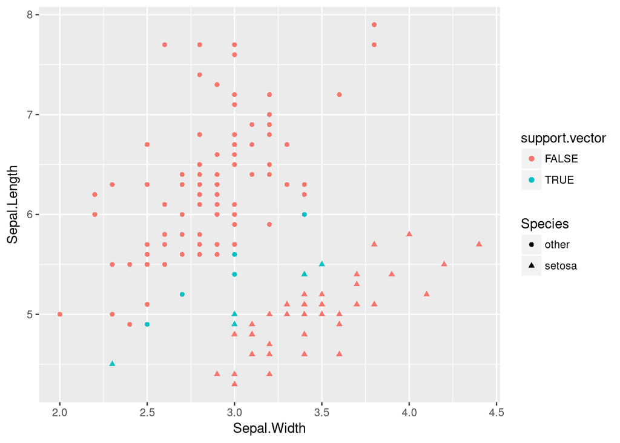

```r
iris2$support.vector <- FALSE
iris2$support.vector[m$index] <- TRUE

ggplot(iris2,
       mapping = aes(x = Sepal.Width,
                     y = Sepal.Length,
                     shape = Species,
                     color = support.vector)) +
    geom_point()
```

We can use the predict method to create more interesting visualizations showing the decision boundary. For that we need to make predictions over the grid spanned by the observed data.

```r
predGrid <- with(iris2,
                 expand.grid(Sepal.Length = seq(min(Sepal.Length),
                                                max(Sepal.Length),
                                                length.out = 200),
                             Sepal.Width = seq(min(Sepal.Width),
                                               max(Sepal.Width),
                                               length.out = 200)))
```

Next make predictions for each value in the grid:

```r
predGrid$predicted <- predict(m, predGrid)
```

and plot the observed and predicted values.

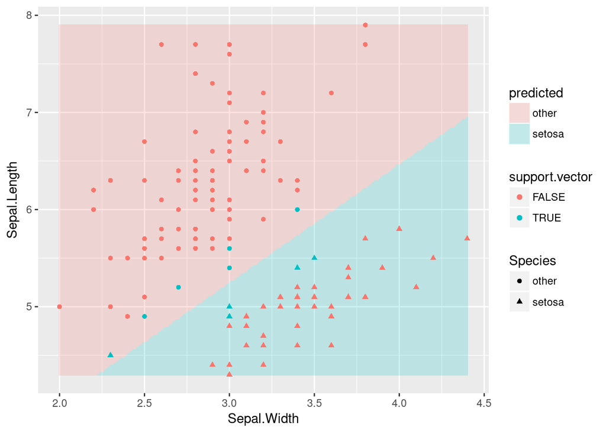

```r
p <- ggplot(predGrid,
            mapping = aes(x = Sepal.Width,
                          y = Sepal.Length)) +
    geom_raster(mapping = aes(fill = predicted),
                alpha = 0.2) +
    geom_point(mapping = aes(shape = Species,
                             color = support.vector),
               data = iris2)
p
```

We can use the predict method to evaluate the classification accuracy.

```r
table(iris2$Species, predict(m, iris2))
```

```
##
##          other setosa
##   other    100      0
##   setosa     1     49
```

# The cost parameter

As we saw in the previous example, the decision boundary need not classify every observation correctly. The SVM algorithm actually selected a decision boundary that left one observation on the wrong side, despite the availability of decision boundaries that correctly classify all the points. This is because the boundary that correctly classifies all the points passes closer (on average) to other points in the support vector.

We can adjust the cost of this constraint violation through the `cost` argument to the `svm` function. This allows us to trade off bias and variance to select a suitable decision boundary.

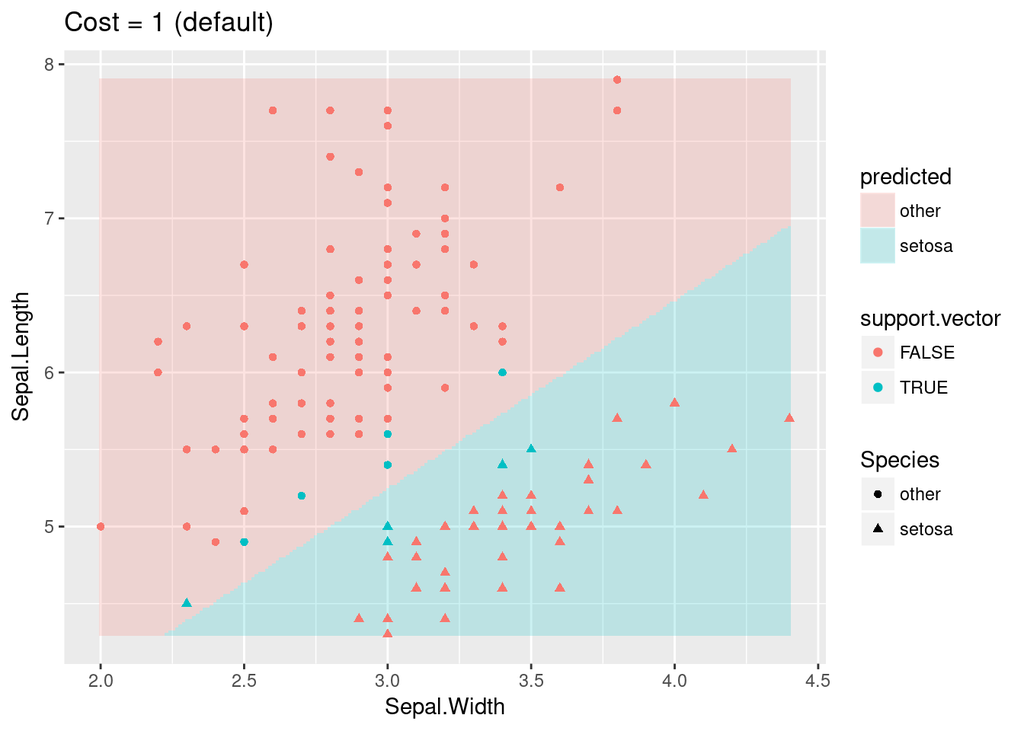

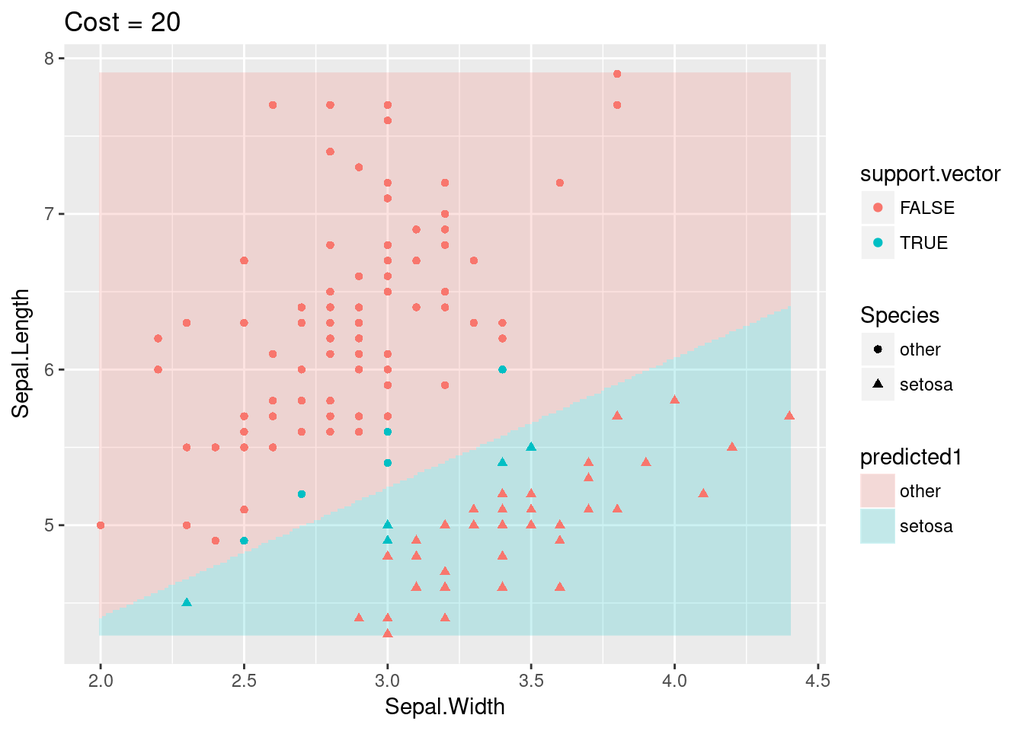

```r
## svm with high cost parameter
m1 <- svm(Species ~ Sepal.Width + Sepal.Length,
         data = iris2,
         kernel = "linear",
         cost = 20)

## predictions on the grid established earlier
predGrid$predicted1 <- predict(m1, predGrid)

## plot
p1 <- ggplot(predGrid,
            mapping = aes(x = Sepal.Width, y = Sepal.Length)) +
    geom_raster(mapping = aes(fill = predicted1),
                alpha = 0.2) +
    geom_point(mapping = aes(shape = Species, color = support.vector),
               data = iris2)

## comparison of predictions with different cost parameters
p + ggtitle("Cost = 1 (default)")
p1 + ggtitle("Cost = 20")
```

By setting a high cost we’re saying that we really want to avoid violating boundary constraints, even at the cost of leaving other points in the support vector closer to the decision boundary. We can think of this as fitting the model more closely to the data, at the possible expense of generalizability.

# A more complicated example

As the classification task becomes more complicated we will usually have to switch to a different kernel. Suppose now that we want to classify `versicolor` vs `other`, using `Petal.Length` and `Petal.Width`.

A simple plot of the data reveals the problem we’ll face:

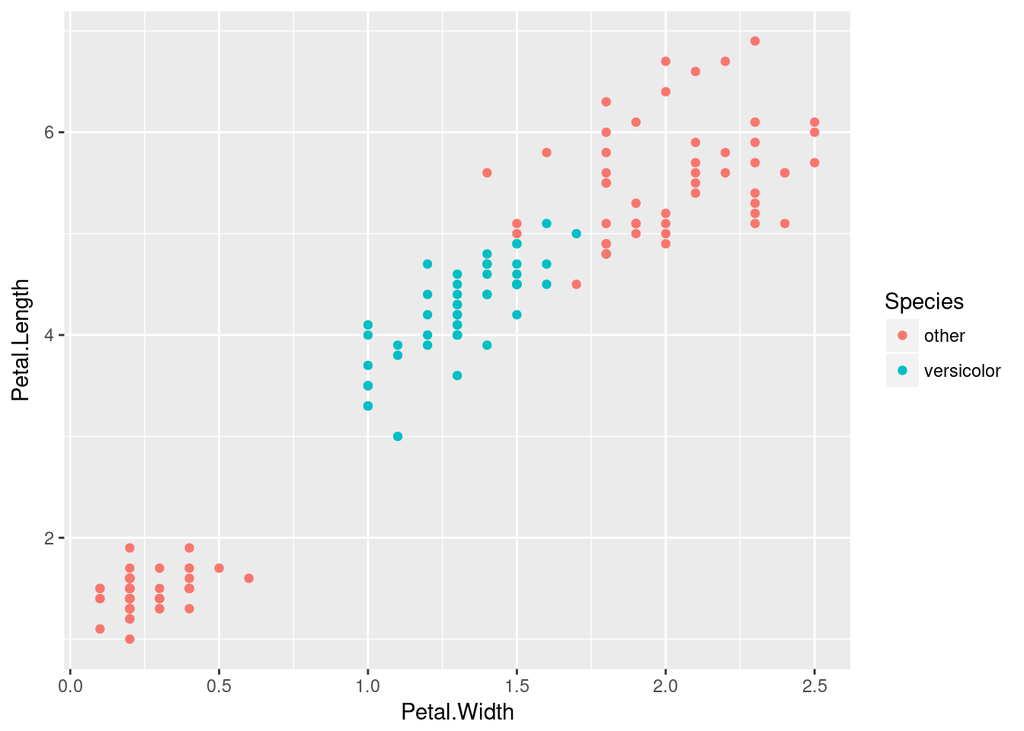

```r
iris2 <- transform(iris,
                   Species = factor(Species == "versicolor",
                                    labels = c("other", "versicolor")))

ggplot(iris2,
       mapping = aes(x = Petal.Width,
                     y = Petal.Length,
                     color = Species)) +
    geom_point()
```

Since `versicolor` is surrounded on both sides by `other`, we won’t have much success with a linear kernel.

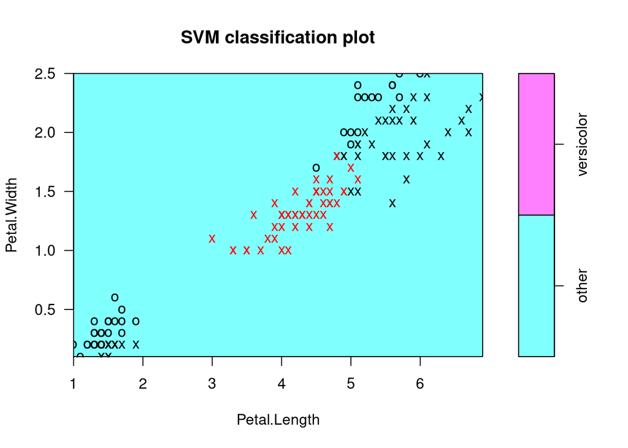

```r
m2 <- svm(Species ~ Petal.Length + Petal.Width,
          data = iris2,
          kernel = "linear")
plot(m2,
     data = iris2,
     formula = Petal.Width ~ Petal.Length)
```

For this type of classification we can switch to a `radial` kernel.

```r
m3 <- svm(Species ~ Petal.Width + Petal.Length,
         data = iris2,
         kernel = "radial")
```

The radial kernel gives much better classification in this scenario:

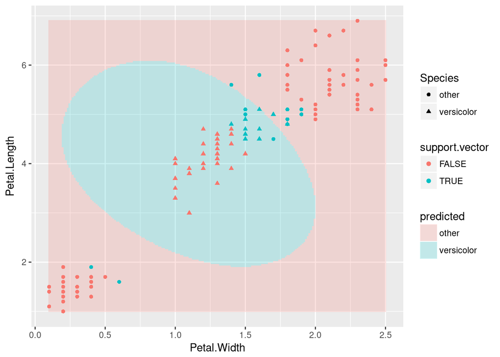

```r
iris2$support.vector <- FALSE
iris2$support.vector[m3$index] <- TRUE

predGrid <- with(iris2,
                 expand.grid(Petal.Length = seq(min(Petal.Length),
                                                max(Petal.Length),
                                                length.out = 200),
                             Petal.Width = seq(min(Petal.Width),
                                               max(Petal.Width),
                                               length.out = 200)))
predGrid$predicted <- predict(m3, predGrid)

p <- ggplot(predGrid,
            mapping = aes(x = Petal.Width,
                          y = Petal.Length)) +
    geom_raster(mapping = aes(fill = predicted),
                alpha = 0.2) +
    geom_point(mapping = aes(shape = Species,
                             color = support.vector),
               data = iris2)
p
```

# The gamma parameter

For non-linear kernels (such as radial) the bias-variance trade-off can be controlled both by the `cost` parameter (as with linear kernels) and by the `gamma` parameter (there is no gamma for a linear kernel). The kernel maps the observed features to a higher-dimensional feature space; the `gamma` parameter controls the “smoothness” of that mapping.

We can see the effect of the `gamma` parameter by varying the value and plotting the predictions.

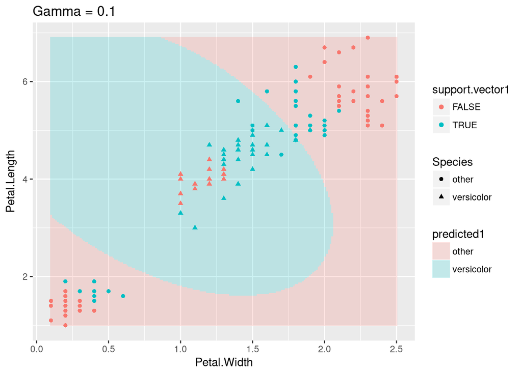

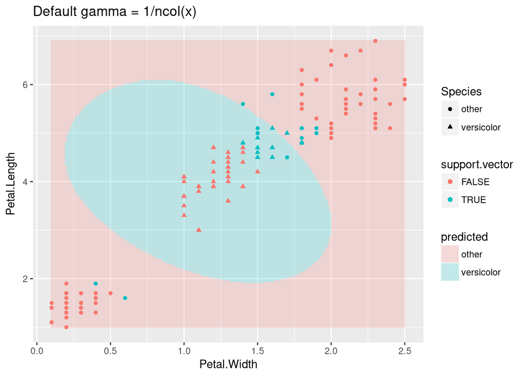

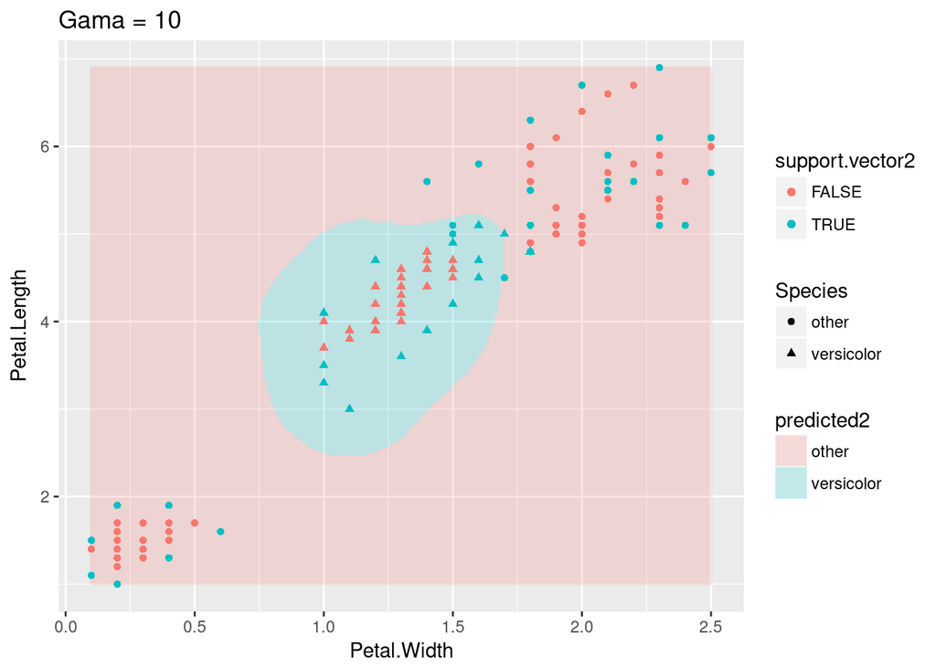

```r
## SVM with gamma = 0.1
m4 <- svm(Species ~ Petal.Width + Petal.Length,
         data = iris2,
         kernel = "radial",
         gamma = 0.1)
## SVM with gamma = 10
m5 <- svm(Species ~ Petal.Width + Petal.Length,
         data = iris2,
         kernel = "radial",
         gamma = 10)

## identify support vectors
iris2$support.vector1 <- FALSE
iris2$support.vector1[m4$index] <- TRUE
iris2$support.vector2 <- FALSE
iris2$support.vector2[m5$index] <- TRUE

## make predictions on the grid
predGrid$predicted1 <- predict(m4, predGrid)
predGrid$predicted2 <- predict(m5, predGrid)

## graph observed and predicted values for each gamma value
p1 <- ggplot(predGrid,
             mapping = aes(x = Petal.Width,
                           y = Petal.Length)) +
    geom_raster(mapping = aes(fill = predicted1),
                alpha = 0.2) +
    geom_point(mapping = aes(shape = Species,
                             color = support.vector1),
               data = iris2)

p2 <- ggplot(predGrid,
             mapping = aes(x = Petal.Width,
                           y = Petal.Length)) +
    geom_raster(mapping = aes(fill = predicted2),
                alpha = 0.2) +
    geom_point(mapping = aes(shape = Species,
                             color = support.vector2),
               data = iris2)


p1 + ggtitle("Gamma = 0.1")
p + ggtitle("Default gamma = 1/ncol(x)")
p2 + ggtitle("Gama = 10")
```

# Tuning cost and gamma

We’ve seen that we can trade off bias and variance via the `cost` and (for non-linear kernels) `gamma`. But what parameter values should we choose?

The `e1071` package provides a `tune` function that can be used to select appropriate parameters via cross validation.

```r
sp.tune <- tune(svm,
                Species ~ Petal.Width + Petal.Length,
                data = iris2,
                ## NOTE: better to try more combinations,
                ## limited here to avoid long computation time
                ranges = list(gamma = seq(2, 30, by = 2),
                              cost = seq(2, 30, by = 2)))

sp.tune
```

```
##
## Parameter tuning of 'svm':
##
## - sampling method: 10-fold cross validation
##
## - best parameters:
##  gamma cost
##     22    6
##
## - best performance: 0.006666667
```

There is a`plot` method that you can use to visualize the performance of your SVM as a function of the tuning parameters:

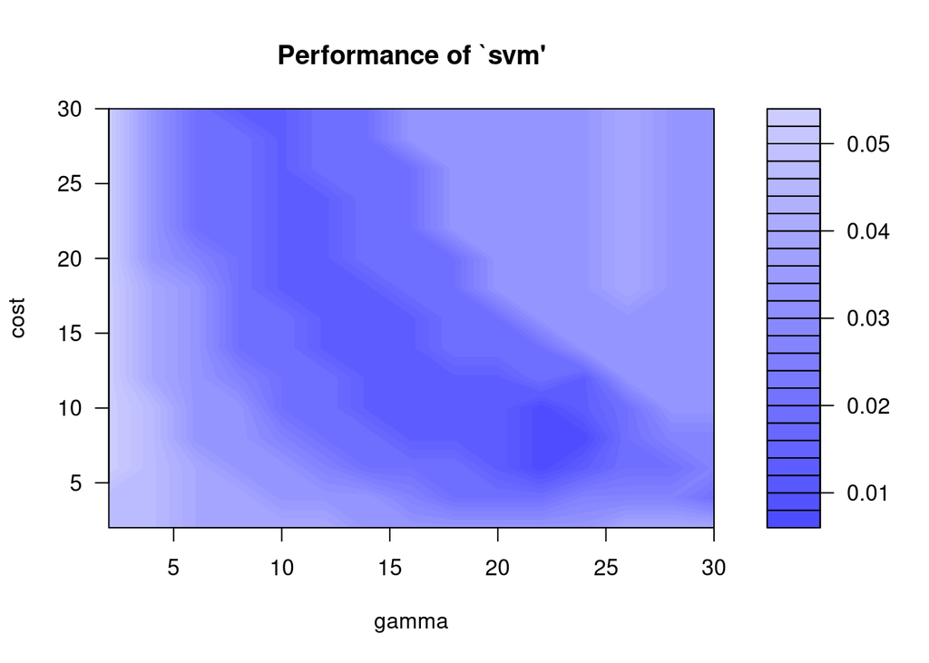

```r
plot(sp.tune)
```

but I don’t really like that way of visualizing performance. Better to do the plotting yourself:

```r
names(sp.tune)
```

```
## [1] "best.parameters"  "best.performance" "method"
## [4] "nparcomb"         "train.ind"        "sampling"
## [7] "performances"     "best.model"
```

```r
str(sp.tune$performances)
```

```
## 'data.frame':    225 obs. of  4 variables:
##  $ gamma     : num  2 4 6 8 10 12 14 16 18 20 ...
##  $ cost      : num  2 2 2 2 2 2 2 2 2 2 ...
##  $ error     : num  0.0467 0.0467 0.04 0.04 0.04 ...
##  $ dispersion: num  0.0549 0.0549 0.0466 0.0466 0.0466 ...
```

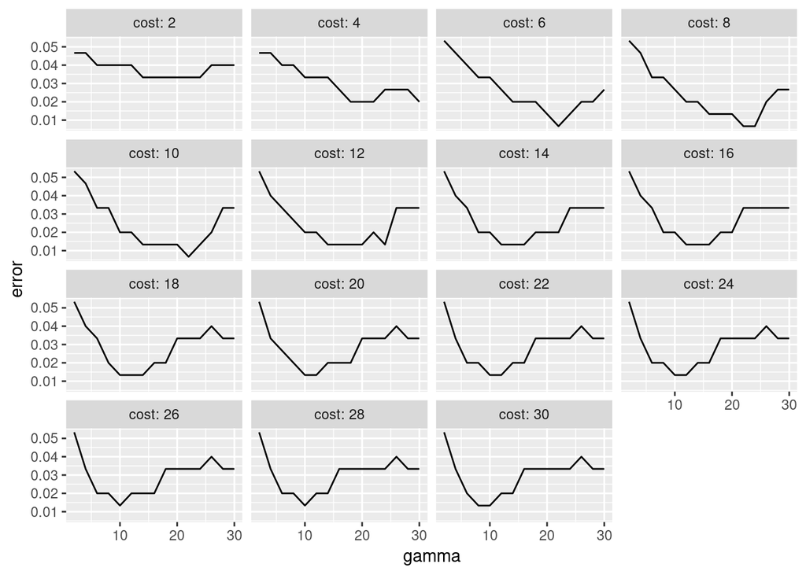

```r
ggplot(sp.tune$performances,
       mapping = aes(x = gamma, y = error)) +
  geom_line() +
  facet_wrap(~cost, labeller = label_both)
```

The `tune` function also returns the best model (among other things). We can use the `best.model` component to predict.

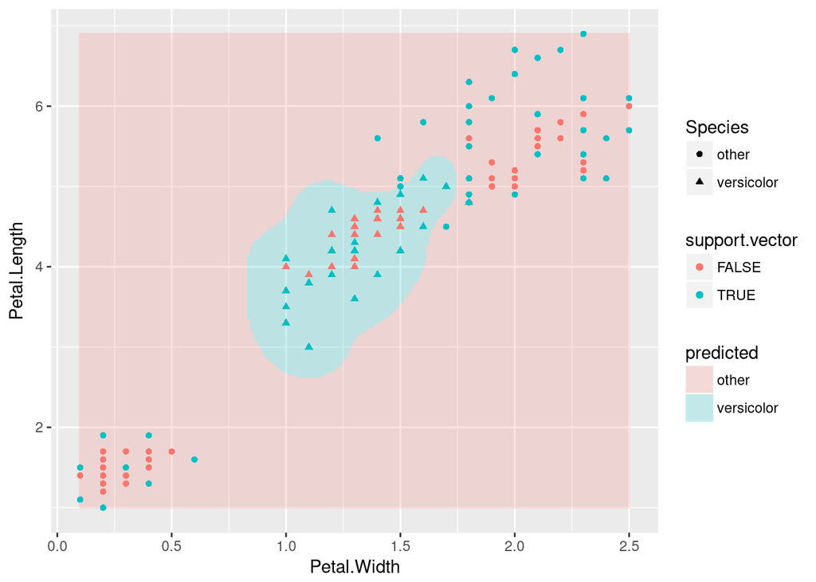

```r
## identify support vectors
iris2$support.vector <- FALSE
iris2$support.vector[sp.tune$best.model$index] <- TRUE

## predict using the grid established earlier
predGrid$predicted <- predict(sp.tune$best.model, predGrid)

## plot
p <- ggplot(predGrid,
            mapping = aes(x = Petal.Width,
                          y = Petal.Length)) +
    geom_raster(mapping = aes(fill = predicted),
                alpha = 0.2) +
    geom_point(mapping = aes(shape = Species,
                             color = support.vector),
               data = iris2)
p
```

*Note When selecting parameter values via cross-validation you should generally hold out a test set to calculate the accuracy of the best model identified through cross-validation on the training set. In these `iris` examples we skipped that step in the interest of focusing on the mechanics of SVM in R.*

# More predictors and classes

In the examples thus far we’ve classified only a single binary response, using only two features as predictors.

## More than two features

Using only two features made it easy to understand what the algorithm does, especially because constructing graphs of the decision boundary is easy in the two-predictor case. However, SVM is by no means limited to two observed features, and indeed using more features will generally improve your classification accuracy. From a practical standpoint there is nothing much to it – just add the additional features to the right-hand-side of the formula argument to `svm`.

## More than two response categories

SVM does not generalize to more than two response categories. In practice this isn’t a huge drawback – we simply use multiple SVMs, each one making a binary classification. This is handled transparently by the `svm` function.

## Multiple class multiple feature example

Again, from a mechanical perspective not much changes when classifying k>2 response categories using more than two features.

```r
m6 <- svm(Species ~ .,
          data = iris)
```

Predict works just as before:

```r
table(iris$Species, predict(m6, data = iris))
```

```
##
##              setosa versicolor virginica
##   setosa         50          0         0
##   versicolor      0         48         2
##   virginica       0          2        48
```

Since our graphical displays are limited to two dimensions we do need to take more care when graphing the predictions.

*Note that the graph below is somewhat more complicated than I would expect you to do – the purpose of the code below is to try to give you some insight into what happens when we have more than two response levels and features.*

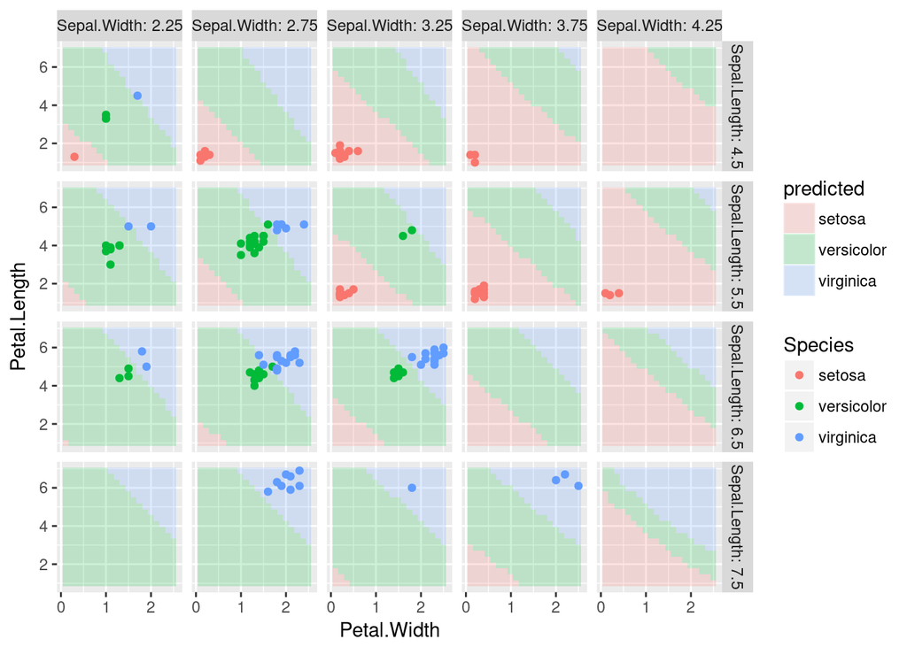

```r
### establish a grid of prediction grids ###

iris2 <- iris

## calculate cut points for each grid
slh <- hist(iris2$Sepal.Length, 4, plot = FALSE)
swh <- hist(iris2$Sepal.Width, 4, plot = FALSE)

iris2$Sepal.Length <- as.numeric(as.character(cut(iris2$Sepal.Length,
                                                  breaks = slh$breaks,
                                                  labels = slh$mids,
                                                  include.lowest = TRUE)))
iris2$Sepal.Width <- as.numeric(as.character(cut(iris2$Sepal.Width,
                                                 breaks = swh$breaks,
                                                 labels = swh$mids,
                                                 include.lowest = TRUE)))

## construct the grid of prediction grids
predGrid <- with(iris2,
                 expand.grid(Petal.Length = seq(min(Petal.Length),
                                                max(Petal.Length),
                                                length.out = 20),
                             Petal.Width = seq(min(Petal.Width),
                                               max(Petal.Width),
                                               length.out = 20),
                             Sepal.Length = unique(Sepal.Length),
                             Sepal.Width = unique(Sepal.Width)))

### make predictions ###
predGrid$predicted <- predict(m6, predGrid)

### plot petal width vs petal length for each sepal length X width grid ###
p <- ggplot(predGrid,
            mapping = aes(x = Petal.Width, y = Petal.Length)) +
    geom_raster(mapping = aes(fill = predicted),
                alpha = 0.2) +
    geom_point(mapping = aes(color = Species),
               data = iris2) +
    facet_grid(Sepal.Length ~ Sepal.Width, labeller = label_both)
p
```

# Your turn: Detecting forgeries

The UC Irvine Machine Learning Repository contains a wealth of interesting data sets. The data at https://archive.ics.uci.edu/ml/machine-learning-databases/00267/data_banknote_authentication.txt contains data about the properties of images of real and counterfeit bank notes.

Some documentation is available at https://archive.ics.uci.edu/ml/datasets/banknote+authentication#. Note that there are not headers in the data file: the column names are “variance”, “skew”, “curtosis”, “entropy”, and “class”.

Unfortunately the documentation is a bit sparse – for now let’s assume that `class == 0` is real and `class == 1` counterfeit, although it could be vice versa.

Our goal is to classify these images as real or counterfeit.

1. Read the data into R. Ensure that the columns are named correctly and that `class` is a factor.
2. Split the data into train and test sets.
3. Visually examine the associations among the features by class.
4. Predict `class` using only `skew` and `entropy`.
- Plot `skew` vs `entropy`, coloring by `class`. Based on this visualization, what kernel will you use in your SVM?
- Use the `svm` function to classify banknotes in the training set.
- Plot the actual and predicted class in the test data
- Generate a confusion matrix using the test data as the criterion.
5. Classify banknotes using all available information.
- Use the `tune` function select optimal `cost` and `gamma` parameter values (use all the available features).
- Generate a confusion matrix using the test data as the criterion.